# Lab 4 - Checkpoint 5

Arnaldo Gualberto

06/06/2017

Os dados originais são de uma amostra do Github que correspondem a quantidade de desenvolvedores que alteraram arquivos com certa extensão entre 1º de Janeiro de 2016 e 10 de Maio de 2017. **Neste trabalho, vamos comparar a popularidade de desenvolvedores no Github durante a semana e durante o fim de semana**. Em outras palavras, queremos saber se a quantidade de desenvolvedores durante a semana no Github é significativamente maior que nos finais de semana. Para isso, **vamos utilizar o teste de hipótese com permutação**.

# 0. Imports and Settings

```r
library(dplyr, warn.conflicts = FALSE)
library(ggplot2)
library(knitr)
library(lubridate, warn.conflicts = FALSE)
library(readr)
library(resample)

# Coloca todos os titulos dos gráficos centralizados
theme_update(plot.title = element_text(hjust=0.5))
```

# 1. Carregamento e limpeza dos dados

Primeiramente, vou carregar os dados e efetuar algumas transformações: alterar o nome das colunas para melhor entendimento; criar uma coluna com o dia da semana correspondente; e criar outra coluna dizendo se o dia da semana corresponde a fim de semana (sábado/domingo) ou não. Logo:

```r
dados_github <- read_csv("data/github-data.csv")
names(dados_github) <- c("extensao", "dia", "mes", "ano", "usuarios")

dados_github <- dados_github %>%
  mutate(data = ymd(paste(ano, mes, dia)), dia_da_semana = wday(data, label = T)) %>%
  mutate(fim_de_semana = ifelse(dia_da_semana == "Sat" | dia_da_semana == "Sun", "Sim", "Não"))

head(dados_github) %>% kable()
```

| extensao | dia | mes | ano | usuarios | data | dia_da_semana | fim_de_semana |
| --- | --- | --- | --- | --- | --- | --- | --- |
| md | 18 | 2 | 2016 | 10279 | 2016-02-18 | Thurs | Não |
| md | 17 | 2 | 2016 | 10208 | 2016-02-17 | Wed | Não |
| md | 27 | 1 | 2016 | 10118 | 2016-01-27 | Wed | Não |
| md | 16 | 2 | 2016 | 10045 | 2016-02-16 | Tues | Não |
| md | 26 | 1 | 2016 | 10020 | 2016-01-26 | Tues | Não |
| md | 21 | 3 | 2017 | 10015 | 2017-03-21 | Tues | Não |

# 2. Teste de Hipótese

Antes de efeutar o teste de hipótese, vou plotar novamente o intervalo de confiança para a amostra de desenvolvedores do Github durante a semana e durante o fim de semana:

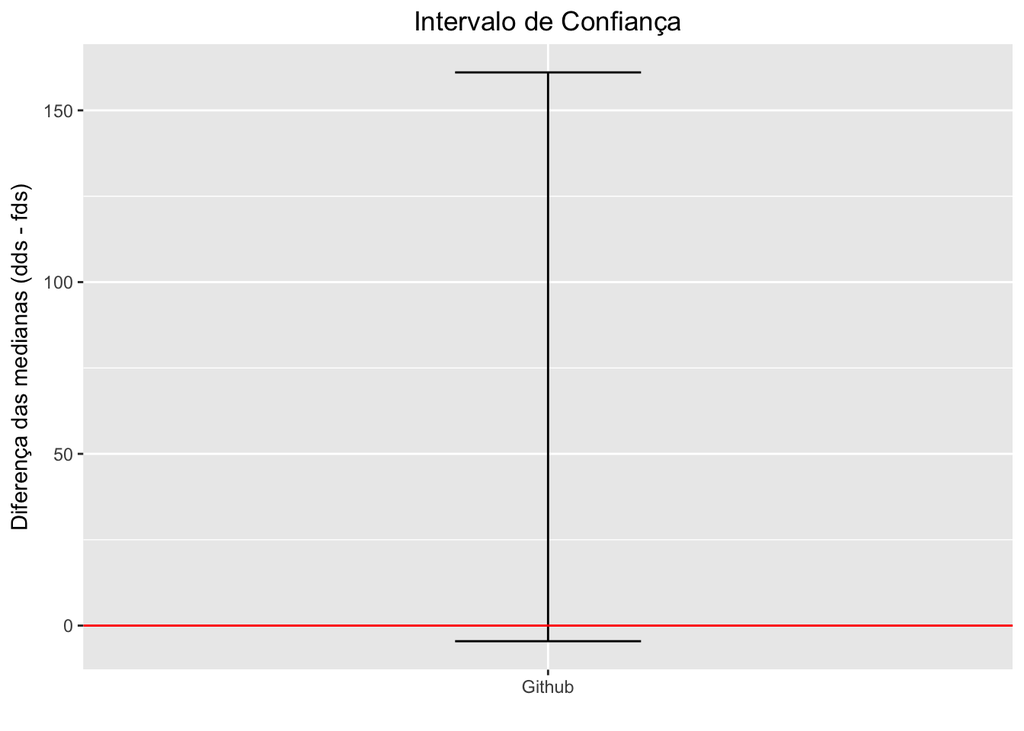

```r
mean.all <- bootstrap2(dados_github, median(usuarios), treatment = fim_de_semana, R = 2000, seed = 42)
ci.all <- mean.all %>% CI.percentile(probs = c(.025, .975))

ci.all %>%
  as.data.frame() %>%
  ggplot(aes(x = "Github", ymin = `2.5%`, ymax = `97.5%`)) +
  geom_errorbar(width = .2) +
  geom_hline(yintercept = 0, color = "red") +
  ggtitle("Intervalo de Confiança") +
  labs(x = "", y = "Diferença das medianas (dds - fds)")
```

```r
ci.all %>% kable()
```

|  | 2.5% | 97.5% |
| --- | --- | --- |
| median(usuarios): Não-Sim | -4.54947 | 161.0495 |

Na atividade anterior concluímos **com 95% de confiança de que não há uma diferença significativa entre a popularidade do github entre o fim de semana e os dias da semana**, visto que o intervalo de confiança cruza o valor zero (linha horizontal vermelha).

Agora, vamos efetuar o teste de hipótese com permutação. Primeiramente, vou definir as hipóteses nula ($H_0$) e alternativa ($H_a$):

- $H_0: M_{dds}=M_{fds}$ (a mediana de desenvolvedores durante a semana é igual ao fim de semana)
- $H_a: M_{dds} \ne M_{fds}$ (a mediana de desenvolvedores durante a semana é diferente em relação ao fim de semana)

Ainda, o teste de hipótese que vamos utilizar será *two-tailed*, com nível de significância $\alpha=0.05$ (95%).

```r
pt <- permutationTest2(dados_github, median(usuarios), treatment = fim_de_semana, alternative = "two.sided", R = 2000, seed = 42)
pt$stats %>% t() %>% kable()
```

|  | median(usuarios): Não-Sim |
| --- | --- |
| Observed | 76.5 |
| Mean | 1.4775 |
| Alternative | two.sided |
| PValue | 0.1509245 |

Logo, **dado que a hipótese nula ($H_0$) é verdadeira, a probabilidade de se obter um teste estatístico mais extremo que o observado é 0.1509245. Como $p\mbox{-}value > 0.05$, não podemos rejeitar $H_0$. Portanto, não há uma diferença significativa entre a popularidade de desenvolvedores durante a semana e durante o fim de semana**.

Finalmente, em comparação com o lab anterior - onde foi utilizado o intervalo de confiança-, podemos dizer que o teste de hipótese é mais fácil de aplicar. Porém, pessoalmente considero o intervalo de confiança mais intuitivo do que o *p-value* e, por ser visual, mais fácil de interpretar.